# Forecasting crime for strategic crime analysis a comparison of methods

Matt Ashby  
UCL Department of Security and Crime Science

## What forecasting is not

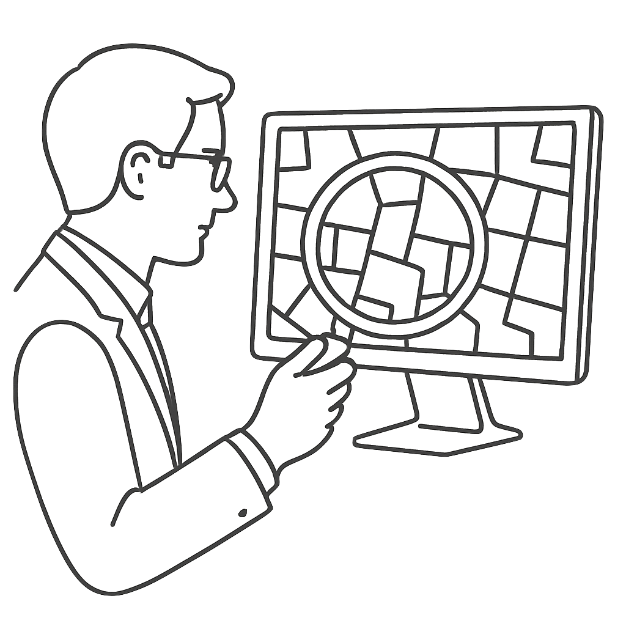

**Predictive policing**

Time: hours/days into future

Geography: streets or grid cells

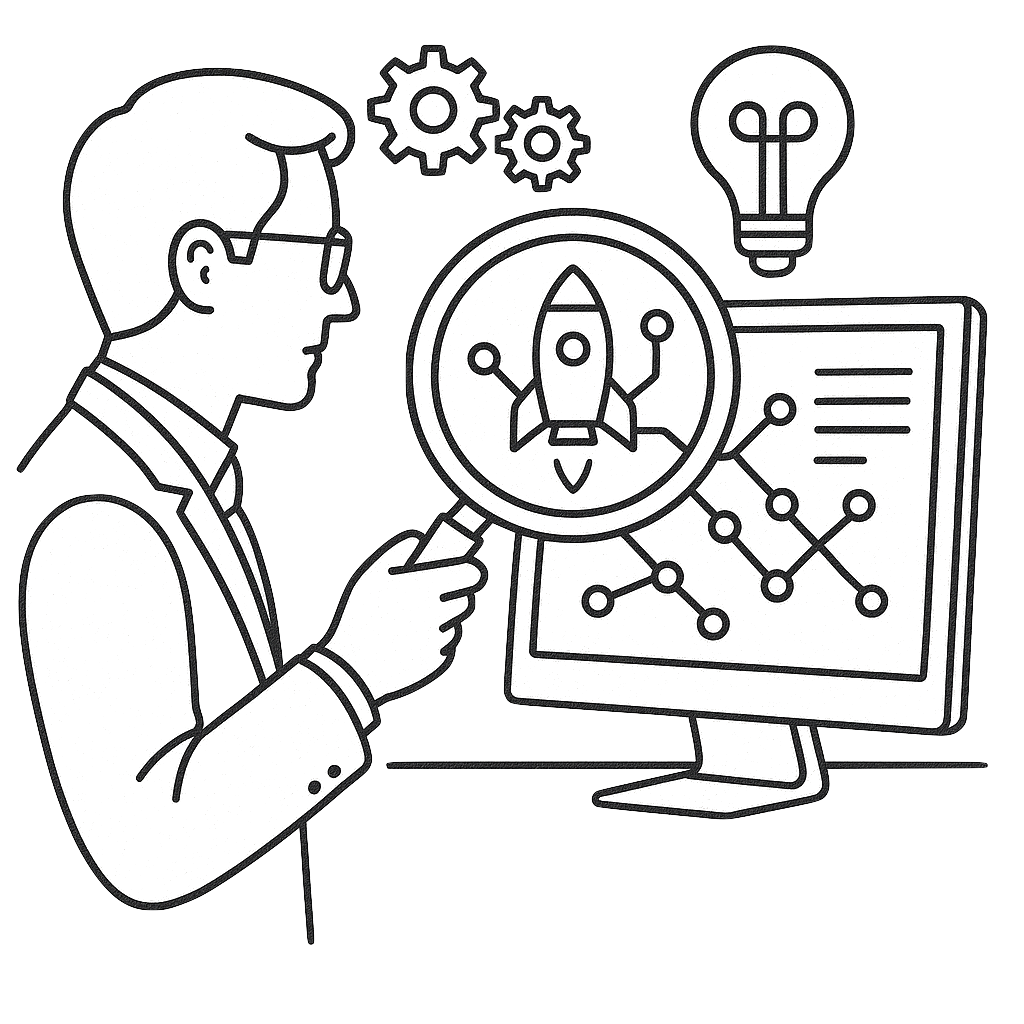

**Horizon scanning**

Time: (many) years into future

Geography: national/international

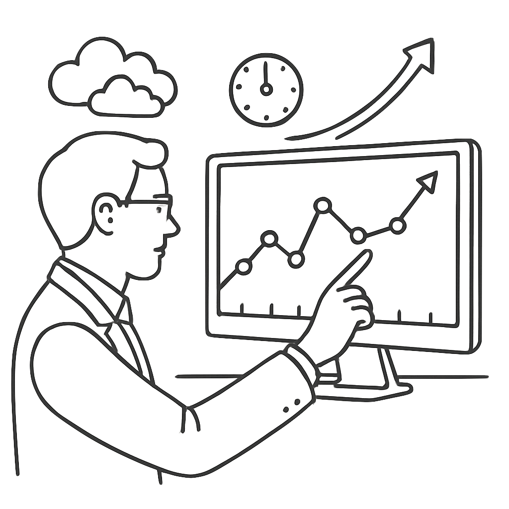

**Crime forecasting**

Time: weeks/months into future

Geography: national/force/district

## Forecasting uses data on the frequency of events …

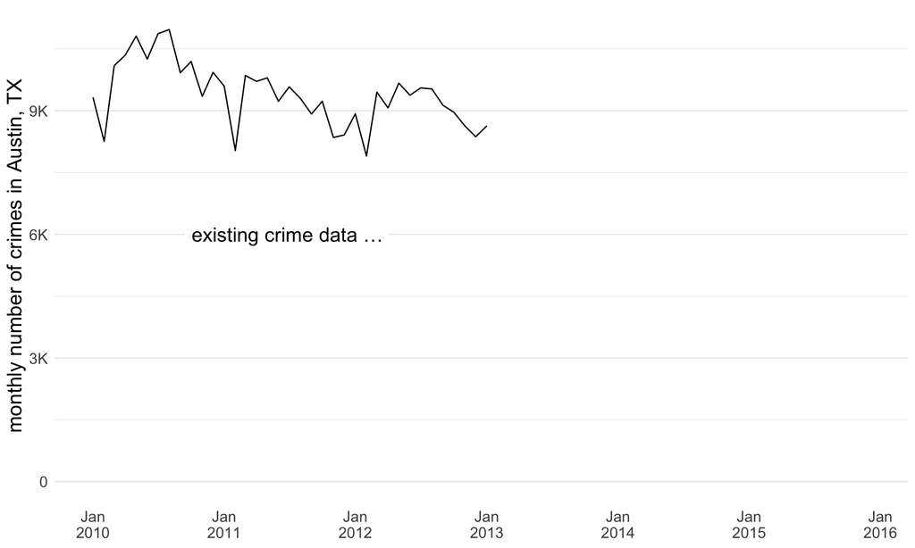

## … to estimate how many events will occur in the future

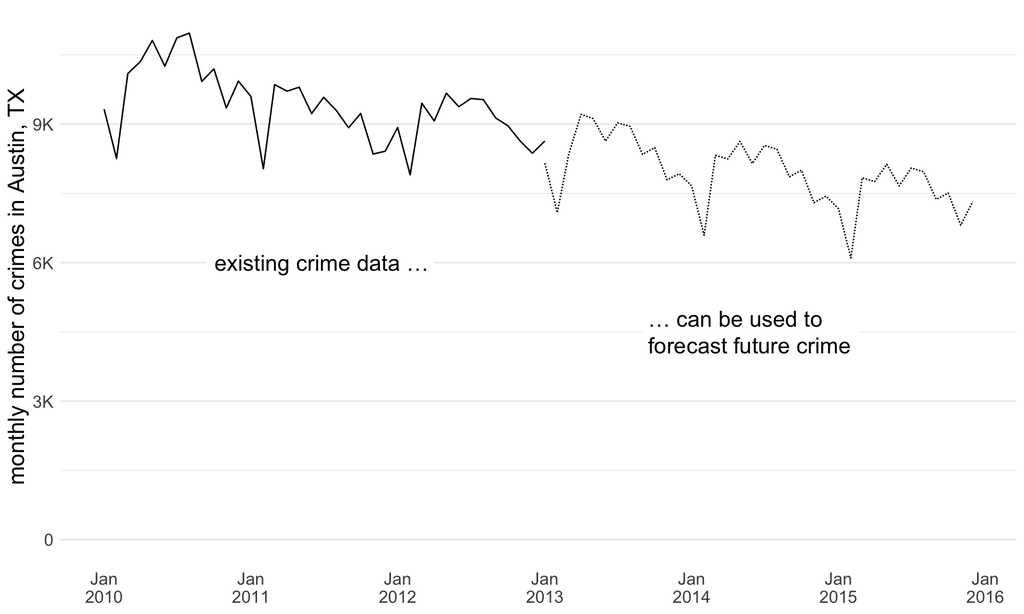

## Forecasting breaks down time series into components

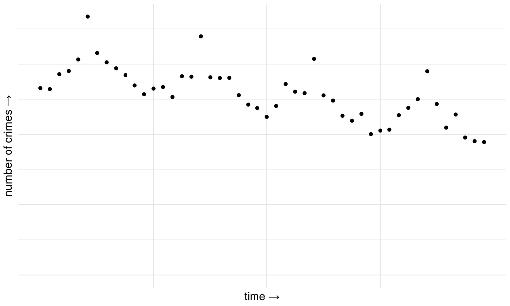

## Time series = trend +

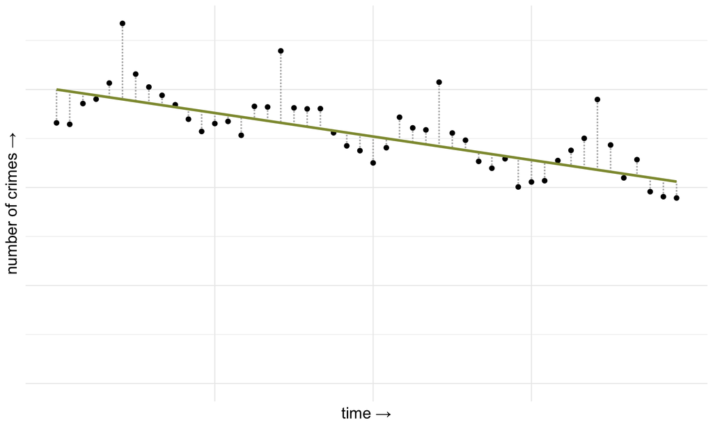

## Time series = trend + season +

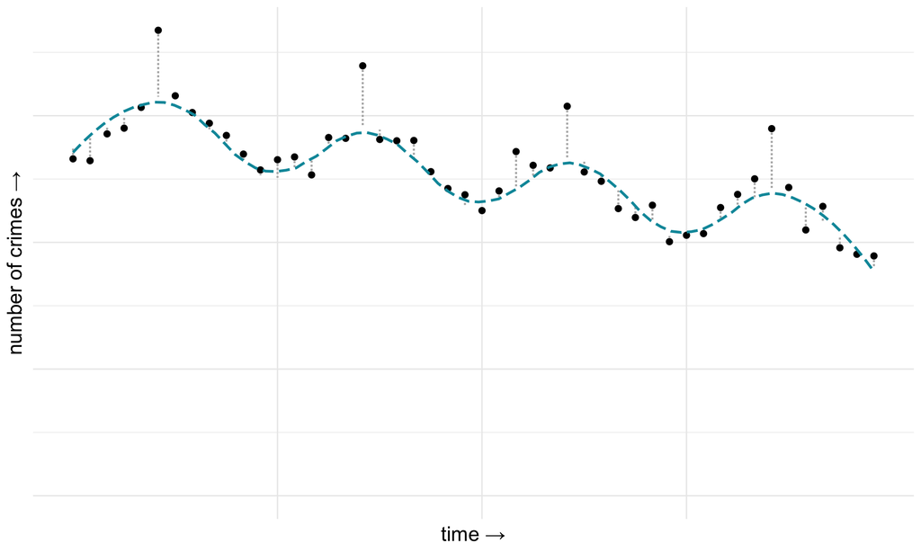

## Time series = trend + season + other

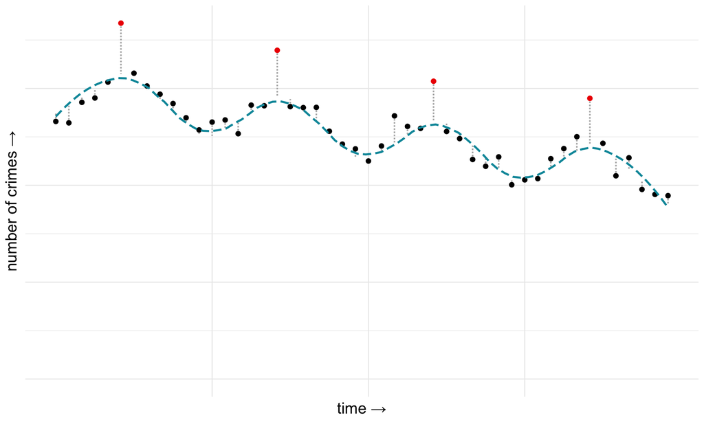

## Many repeating and one-off events can influence time series

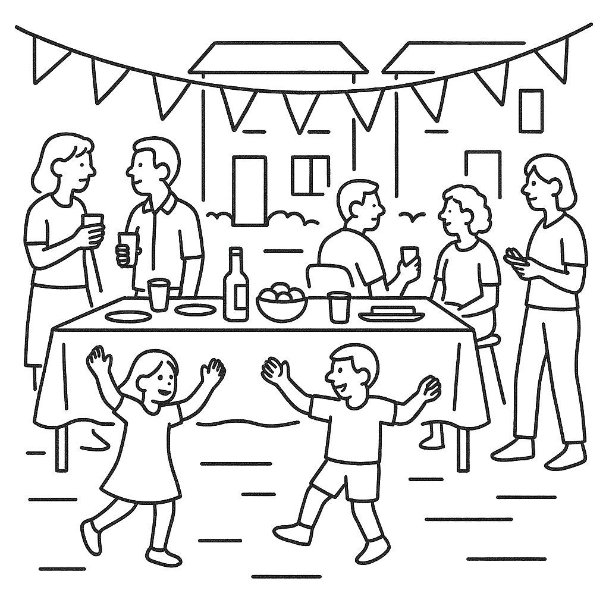

Public holidays

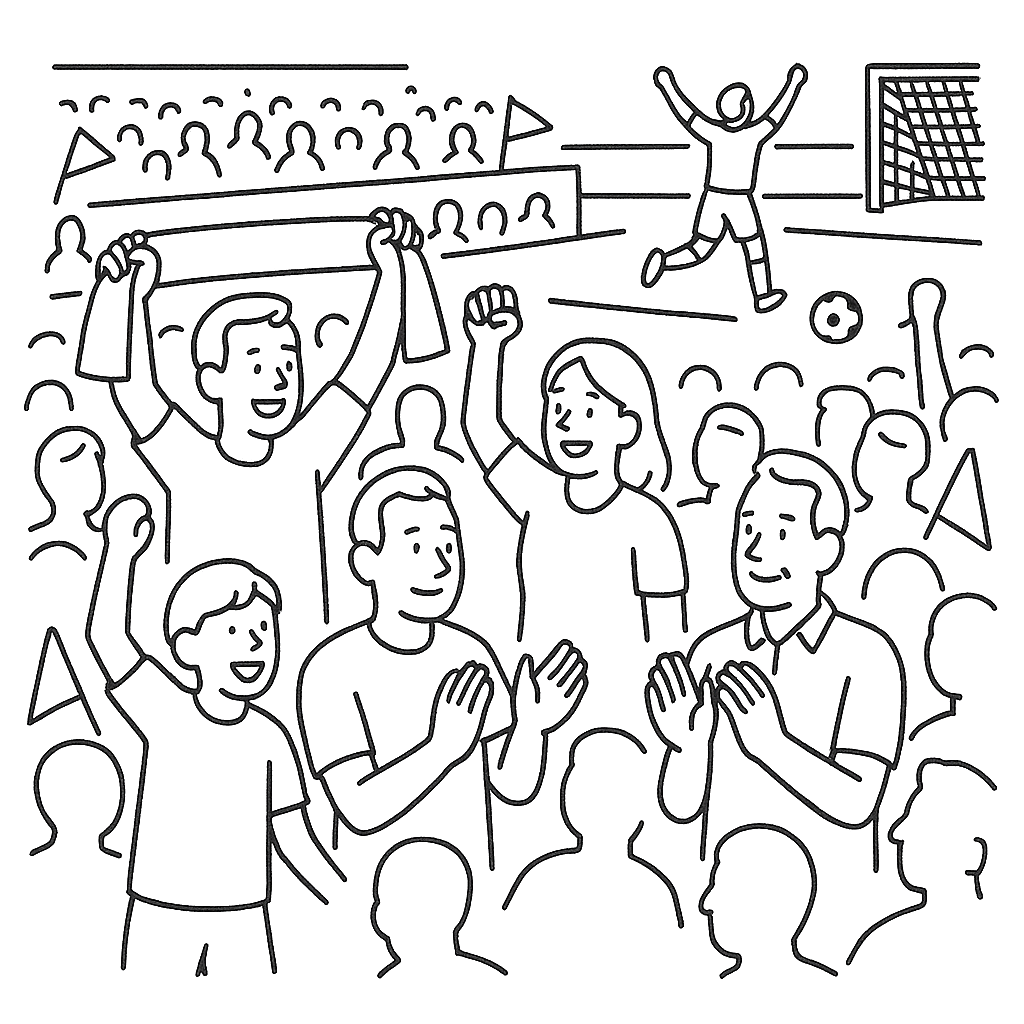

Sporting events, festivals, etc.

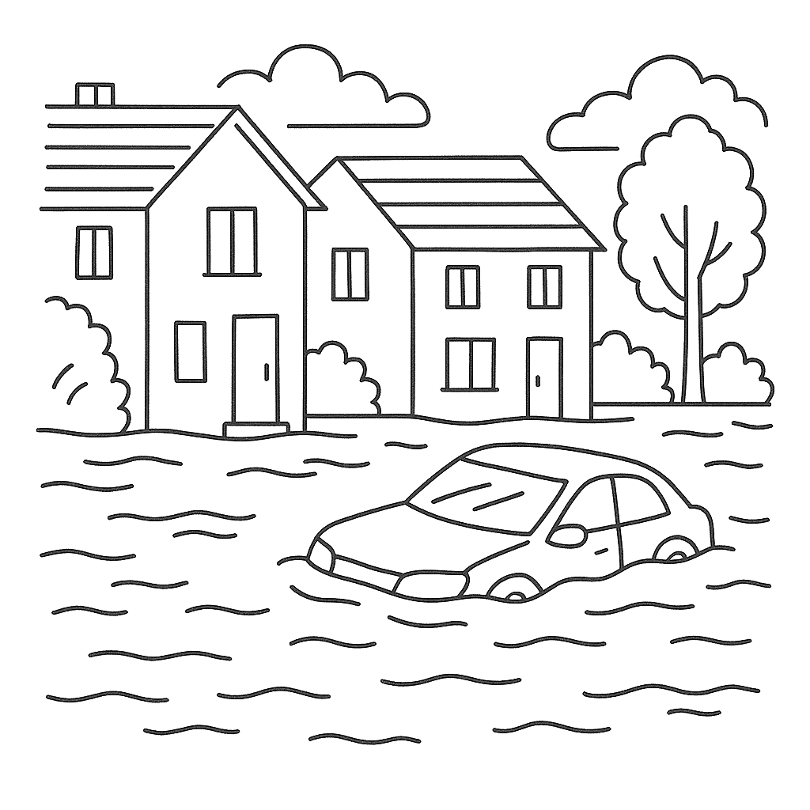

Emergencies

These are sometimes called *exogenous* variables or components

## Forecasting relies on *structural stability*

**But …**

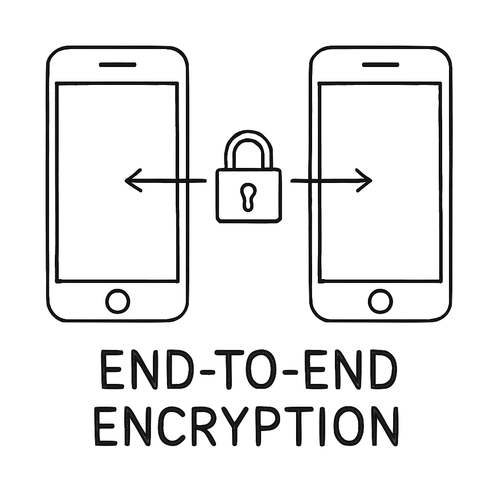

… new technologies change crime patterns

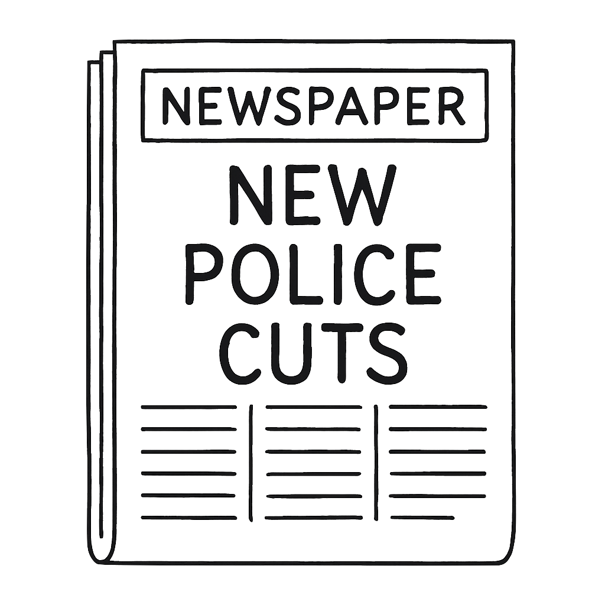

… policing itself changes

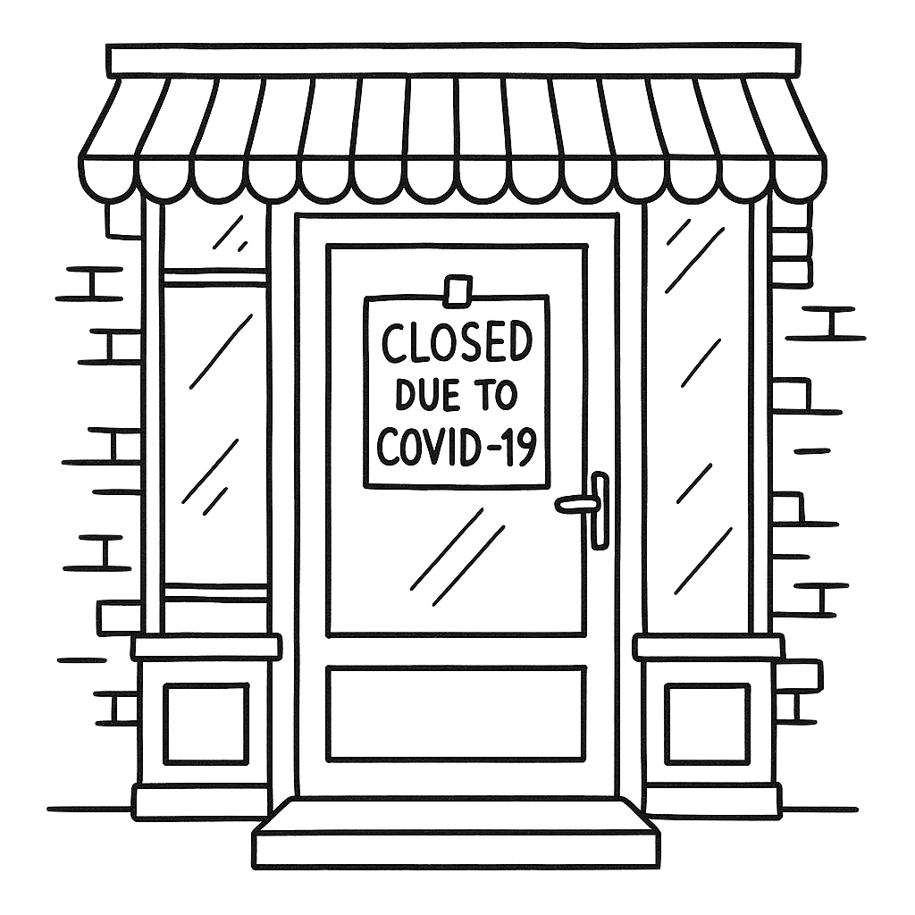

… unexpected events happen

Forecasts should be expressed as:

> If the factors underlying crime remain broadly the same, we expect …

## How forecasting could potentially be useful to policing

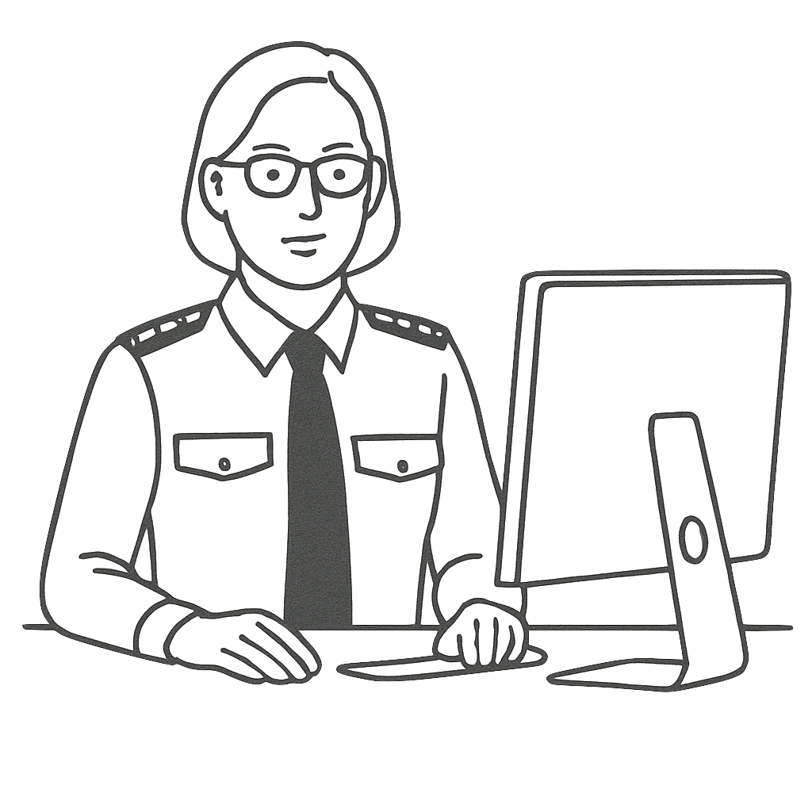

**Scenario 1**

A police commander preparing a budget request wants to know how many crimes are likely to occur in a city each month for the next three years

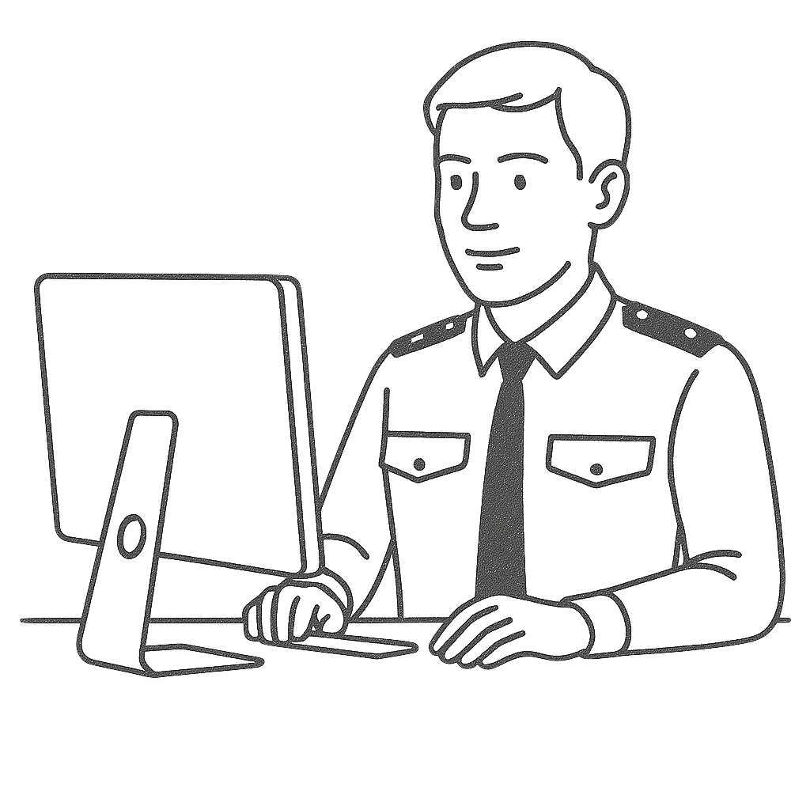

**Scenario 2**

The officer in charge of shift assignments wants to know how many crimes are likely to occur each day for the next three months.

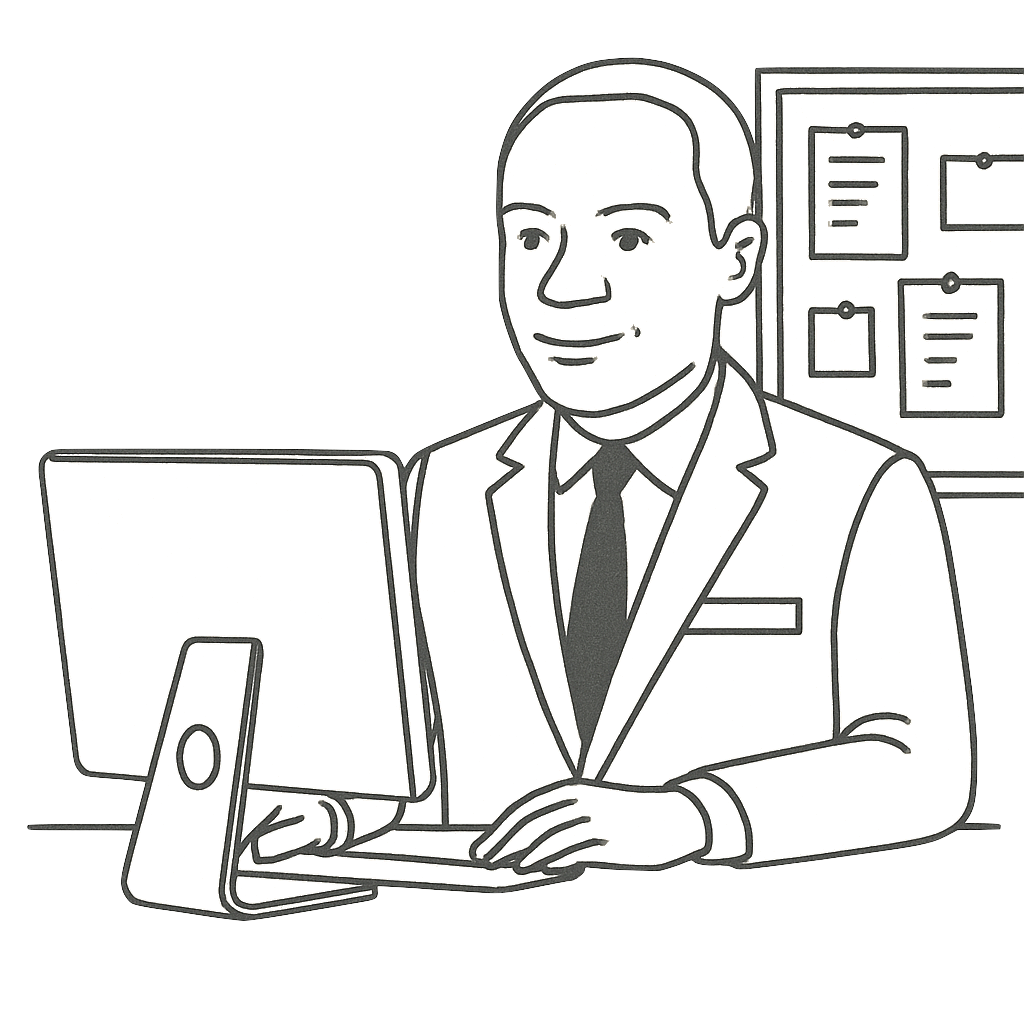

**Scenario 3**

## Crime analysts

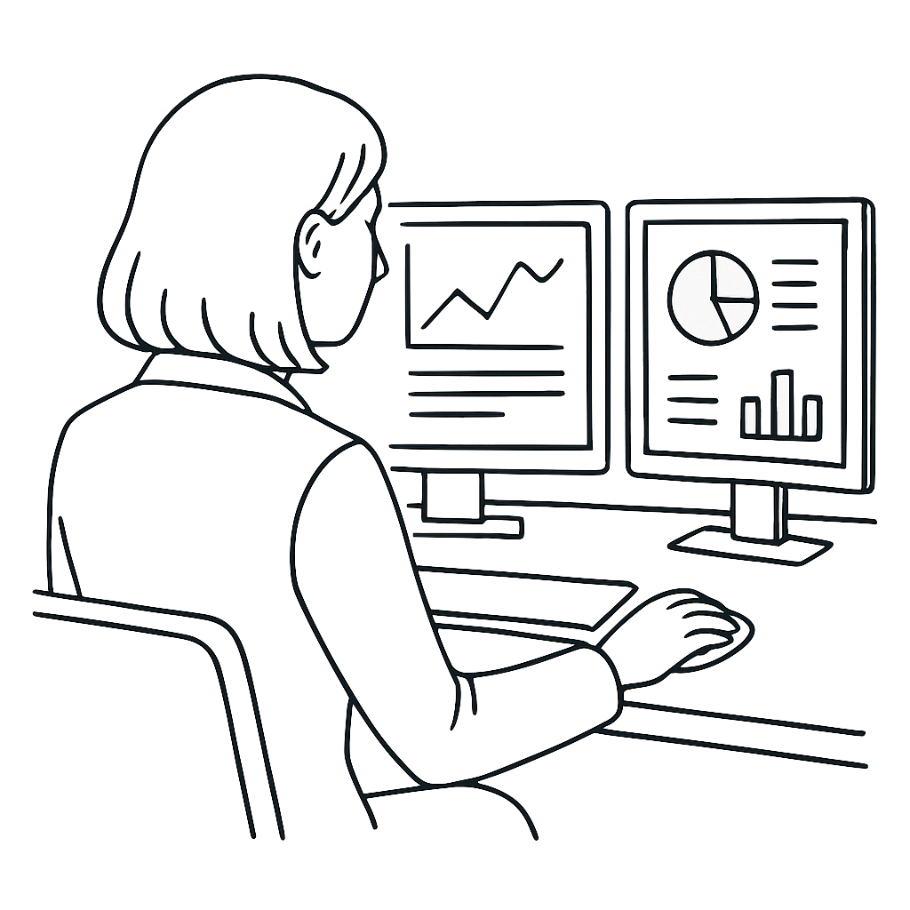

- must master lots of skills
- have limited time
- often have limited software access

⇒ need forecasting to be *semi-automatic*

## The current study

compared 10 forecasting methods

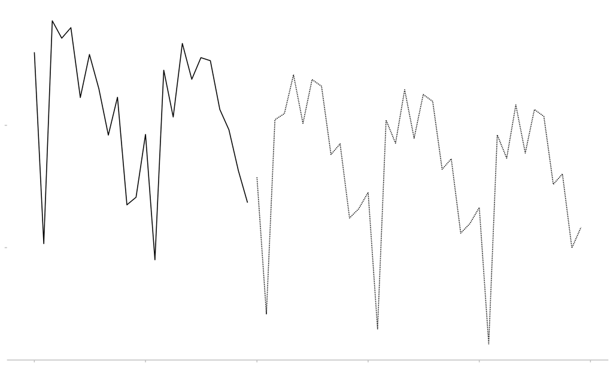

using crime data from 12 US cities

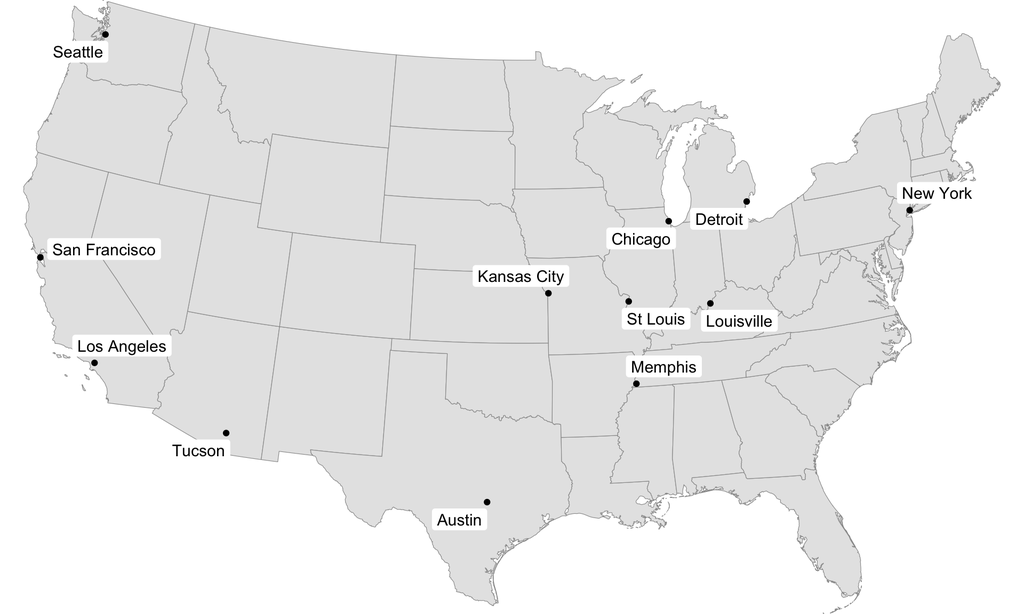

with 36 tests of each scenario in each city

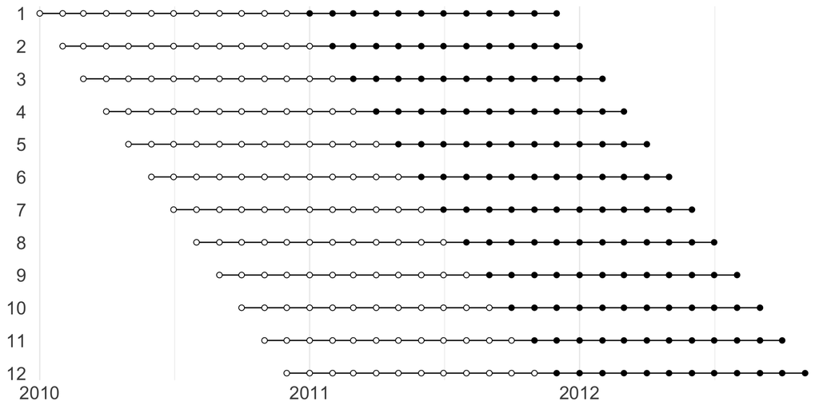

⇒ 1,296 tests of the performance of each forecasting method

[figure not shown]

combined (‘ensemble’) model = mean of ETS, linear model, seasonal naïve and STL forecasts

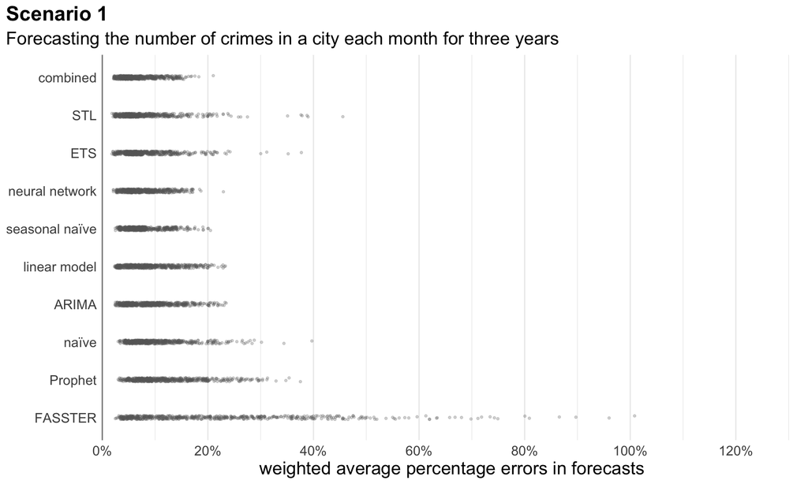

combined (‘ensemble’) model = mean of ETS, linear model, seasonal naïve and STL forecasts

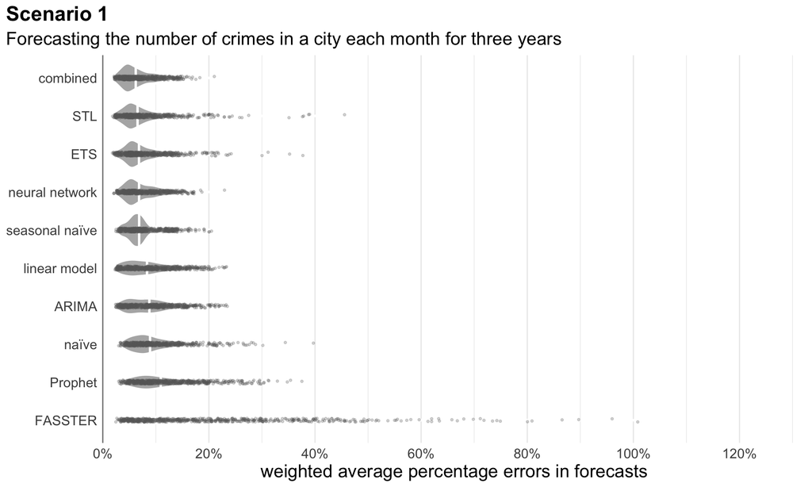

combined (‘ensemble’) model = mean of ETS, linear model, seasonal naïve and STL forecasts

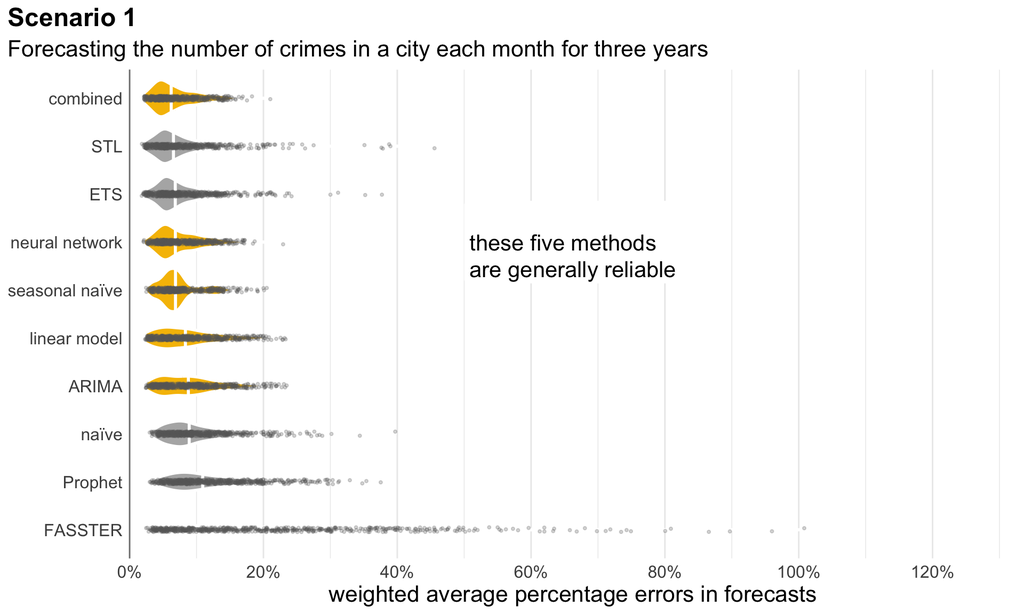

combined (‘ensemble’) model = mean of ETS, linear model, seasonal naïve and STL forecasts

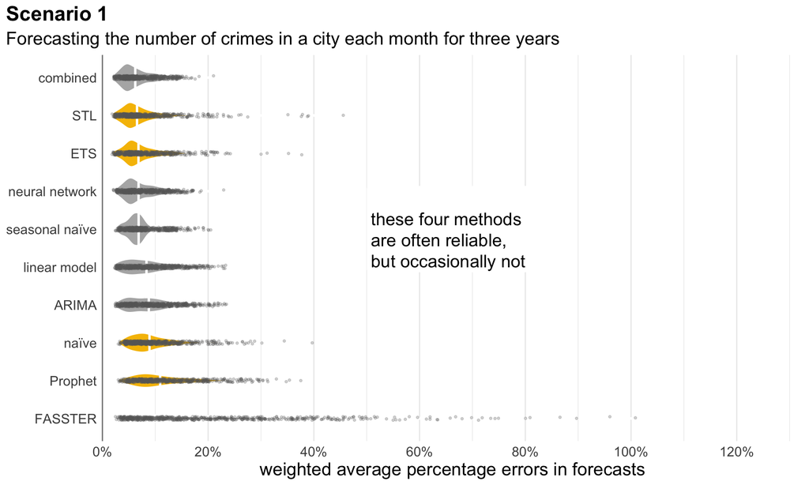

combined (‘ensemble’) model = mean of ETS, linear model, seasonal naïve and STL forecasts

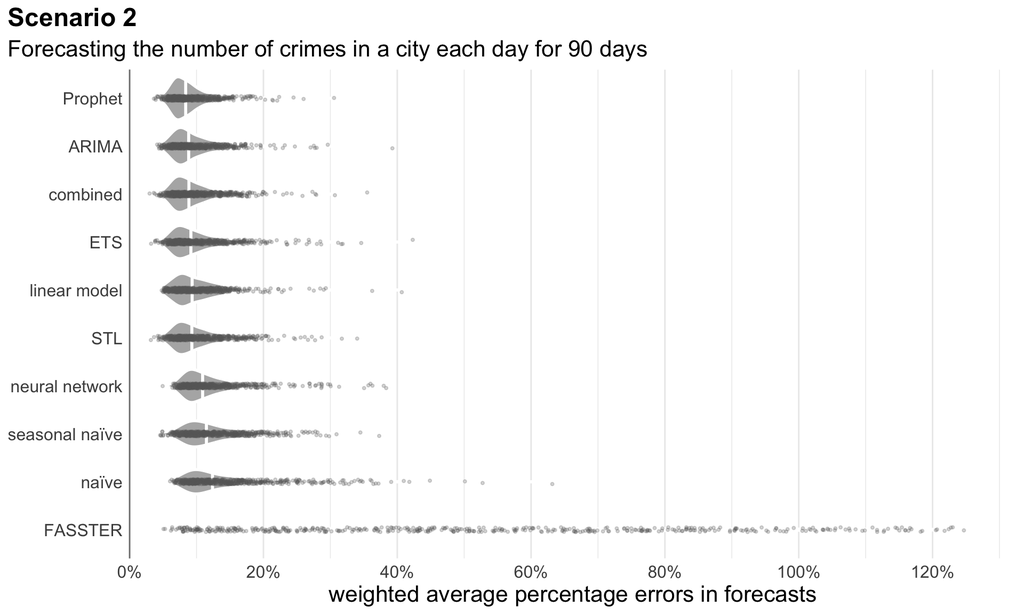

combined (‘ensemble’) model = mean of ETS, linear model, seasonal naïve and STL forecasts

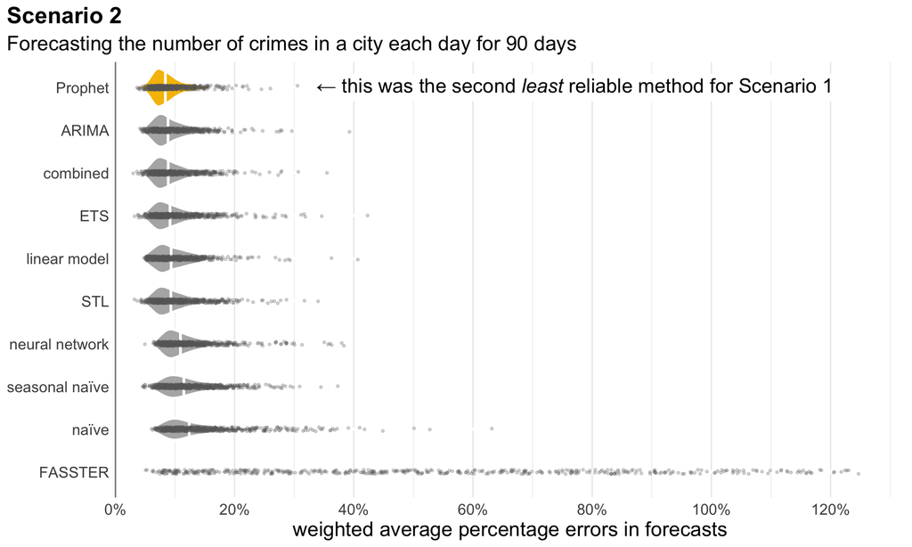

combined (‘ensemble’) model = mean of ETS, linear model, seasonal naïve and STL forecasts

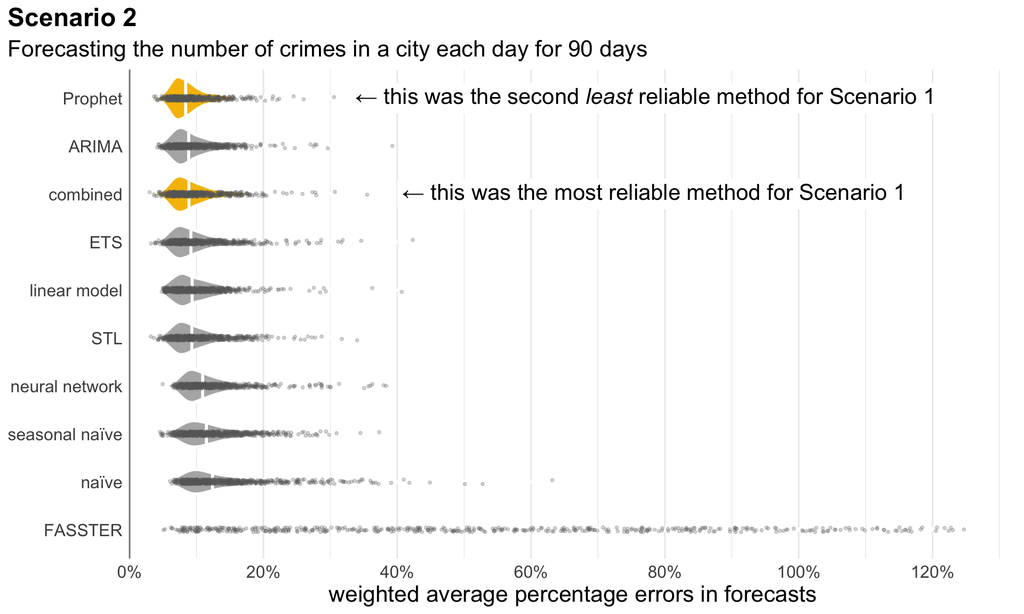

combined (‘ensemble’) model = mean of ETS, linear model, seasonal naïve and STL forecasts

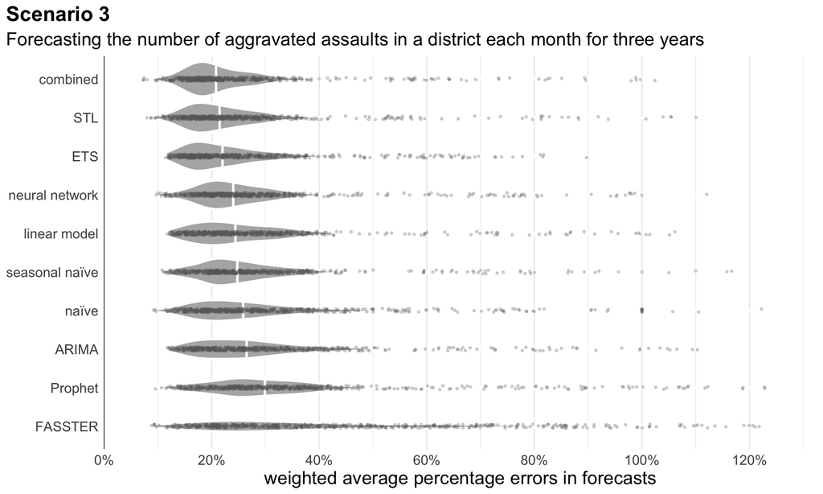

combined (‘ensemble’) model = mean of ETS, linear model, seasonal naïve and STL forecasts

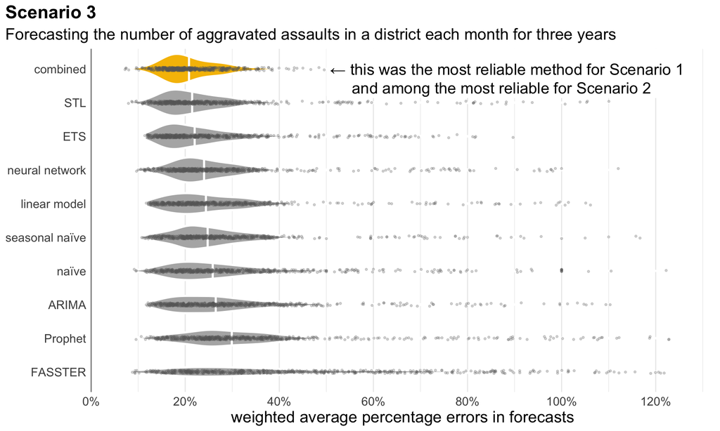

combined (‘ensemble’) model = mean of ETS, linear model, seasonal naïve and STL forecasts